# HMMs: generation and inference

### Toy example 1

Generate data with the hidden state transitions ${\mathbf{A}}= \begin{pmatrix} 0.9 & 0 & 0.1 \\ 0.1 & 0.9 & 0 \\ 0 & 0.1 & 0.9 \end{pmatrix}$ and the emission probabilities ${\mathbf{B}}= \begin{pmatrix} 0.5 & 0 & 0 & 0.5 \\ 0 & 0 & 0.5 & 0.5 \\ 0.6 & 0.4 & 0 & 0 \end{pmatrix}$ A sequence of $x$ and $y$ of length $n=500$.

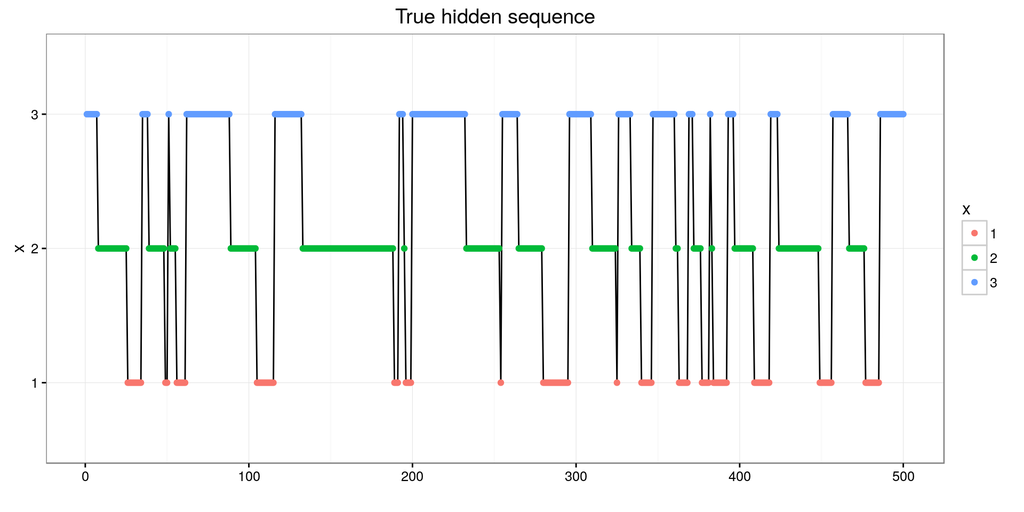

```r
pi = c(1/3, 1/3, 1/3)
A = rbind(c(0.9, 0, 0.1), c(0.1, 0.9, 0), c(0, 0.1, 0.9))
B = rbind(c(0.5, 0, 0, 0.5), c(0, 0, 0.5, 0.5), c(0.6, 0.4, 0, 0))

n = 500
hmm_obs = generate_discrete_HMM(n, pi, A, B)
df_true = data.frame(t = 1:n, x = hmm_obs$x)
ggplot(df_true, aes(t, x, group=1)) +
  geom_path() + geom_point(aes(col = x)) +
  theme_bw() + xlab("") + ggtitle("True hidden sequence")
```

#### Inference

Use Gibbs sampling to iteratively draw samples of

- latent sequences $x_{1:T}$ from $p(x_{1:T} | y_{1:T}, \theta)$
- parameters $\theta := (\pi, {\mathbf{A}}, {\mathbf{B}})$ from $p(\theta | x_{1:T}, y_{1:T})$

```r
res = gibbs_sampling_hmm(y = hmm_obs$y, n_hidden_states = nrow(A), alpha0 = 0.1, max_iter = 1500, burnin = 500)
```

```
## iter 100
## iter 200
## iter 300
## iter 400
## iter 500
## iter 600
## iter 700
## iter 800
## iter 900
## iter 1000
## iter 1100
## iter 1200
## iter 1300
## iter 1400
## iter 1500
```

```r
# relabel the latent states to obtain best match to the true B matrix
res_relabelled = match_states(res$trace_x, res$trace_A, res$trace_B, true_x = hmm_obs$x, k = nrow(A))
```

Note that the labelling of the latent states is arbitrary, i.e. the model specification is invariant to relabelling the states. Here we relabel the latent states of each mcmc sample, choosing the (re)labelling permutations with the highest pointwise accuracy w.r.t. the true x.

#### Visualise samples of $x_{1:T}$

Each draw from the posterior is shown as a grey line. The true states are shown as coloured points.

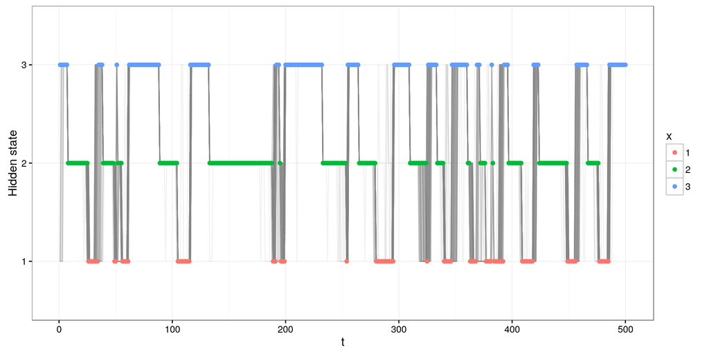

#### Traceplots of the elements in ${\mathbf{A}}$

Panel $(i, j)$ shows the traceplot for the element ${\mathbf{A}}_{ij}$. The red dotted line shows the true value.

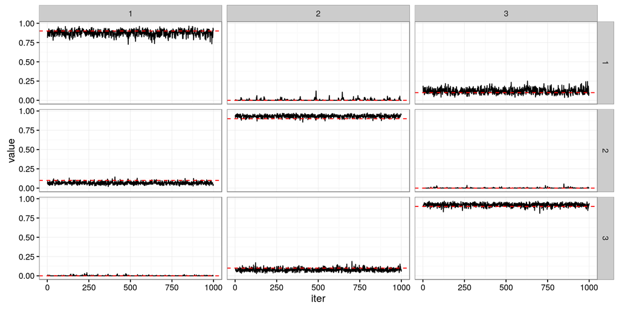

#### Traceplots of the elements in ${\mathbf{B}}$

Panel $(i, j)$ shows the traceplot for the element ${\mathbf{B}}_{ij}$. The red dotted line shows the true value.

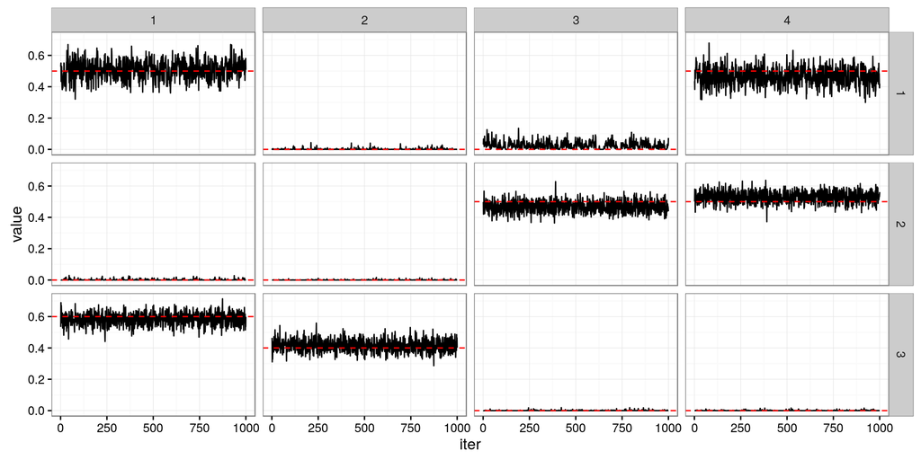

#### Visualise accuracy and switch rate

For each sample of $x_{1:T}$, I calculated two numbers:

- pointwise accuracy – having matched the latent states to be corresponding to true ones, I calculated pointwise accuracy
- switch rate (i.e. the fraction of transitions between states)

Does not seem like a useful plot at the moment, but could become useful when comparing different approaches.

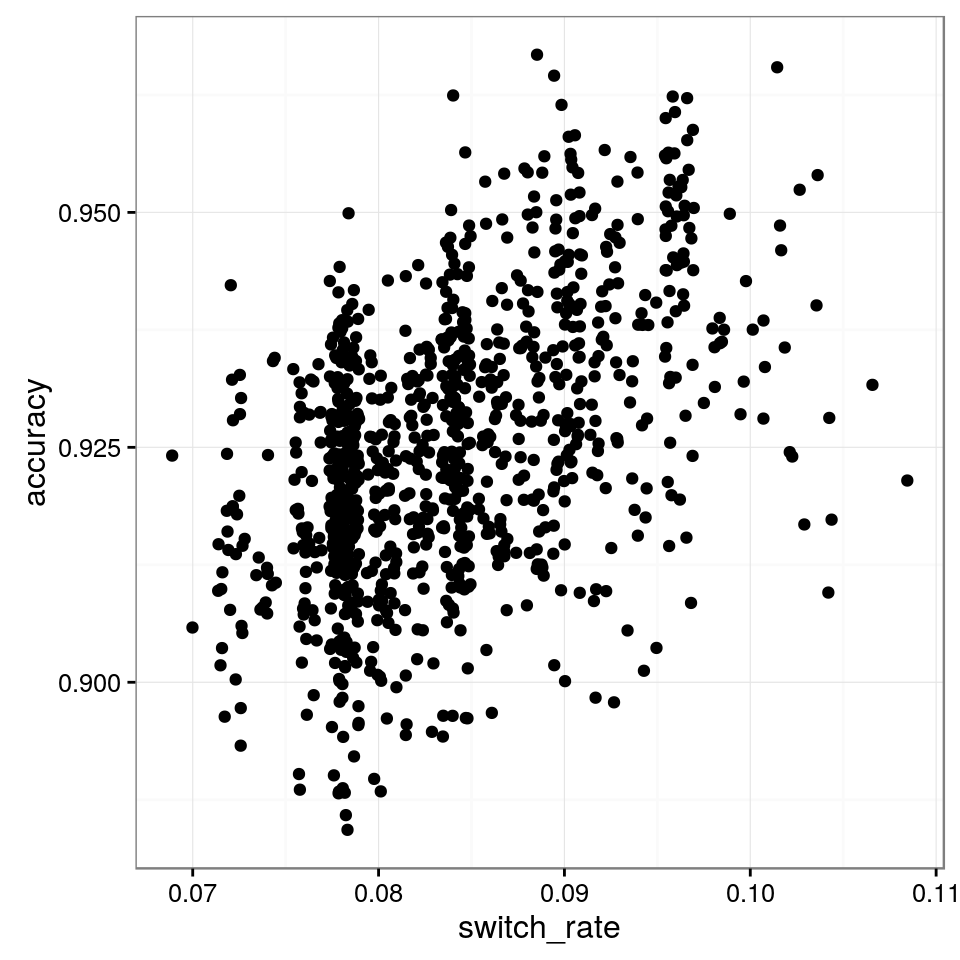